# Visibility Forecasting Model

STAT420, SUMMER 2020, Bipin Chandra Karnati (karnati3), Debajit Mitra(debajit2), Varun Sharma(varun4)

8/4/2020

## **Introduction**

These variables indicate important weather parameters collected over a period of 10 years. As part of this data analysis project, we are trying to understand the relationship among different parameters in the dataset based on our learning in this class. We will focus on observing relationship of visibility with other weather parameters. We will use different statistical models to understand this relationship so that we can also make a good prediction of visibility using those statistical models. Visibility information is essential in air quality monitoring which needs accurate real-time observations. This is the reason we chose historical data observed over a period of 10 years. Visibility is farthest distance that a person with normal vision can recognize a target from the back-ground. Severe reduction of visibility often results in great inconveniences to our life, and even cause major traffic accidents. Thus, it is of great significance to establish an accurate forecast visibility system. Once a forecast model is built, we will test the accuracy of the model by using a subset of real time data that was not used for model building.

## **Methods**

```r
# Loading the data
library(readr)
weather_data = read_csv("weatherHistory.csv")
```

- **Data Analysis**

```r
head(weather_data, 20)
```

```
## # A tibble: 20 x 12
##    `Formatted Date` Summary `Precip Type` `Temperature (C~ `Apparent Tempe~
##    <chr>            <chr>   <chr>                    <dbl>            <dbl>
##  1 2006-04-01 00:0~ Partly~ rain                      9.47             7.39
##  2 2006-04-01 01:0~ Partly~ rain                      9.36             7.23
##  3 2006-04-01 02:0~ Mostly~ rain                      9.38             9.38
##  4 2006-04-01 03:0~ Partly~ rain                      8.29             5.94
##  5 2006-04-01 04:0~ Mostly~ rain                      8.76             6.98
##  6 2006-04-01 05:0~ Partly~ rain                      9.22             7.11
##  7 2006-04-01 06:0~ Partly~ rain                      7.73             5.52
##  8 2006-04-01 07:0~ Partly~ rain                      8.77             6.53
##  9 2006-04-01 08:0~ Partly~ rain                     10.8             10.8
## 10 2006-04-01 09:0~ Partly~ rain                     13.8             13.8
## 11 2006-04-01 10:0~ Partly~ rain                     16.0             16.0
## 12 2006-04-01 11:0~ Partly~ rain                     17.1             17.1
## 13 2006-04-01 12:0~ Partly~ rain                     17.8             17.8
## 14 2006-04-01 13:0~ Partly~ rain                     17.3             17.3
## 15 2006-04-01 14:0~ Partly~ rain                     18.9             18.9
## 16 2006-04-01 15:0~ Partly~ rain                     18.9             18.9
## 17 2006-04-01 16:0~ Partly~ rain                     15.4             15.4
## 18 2006-04-01 17:0~ Mostly~ rain                     15.6             15.6
## 19 2006-04-01 18:0~ Mostly~ rain                     14.3             14.3
## 20 2006-04-01 19:0~ Mostly~ rain                     13.1             13.1
## # ... with 7 more variables: Humidity <dbl>, `Wind Speed (km/h)` <dbl>, `Wind
## #   Bearing (degrees)` <dbl>, `Visibility (km)` <dbl>, `Loud Cover` <dbl>,
## #   `Pressure (millibars)` <dbl>, `Daily Summary` <chr>
```

Based on the initial analysis of the data - *The column “Loud COver” seems to have all zeros in the input dataset. Since this doesn’t add any value we are removing this column.*

```r
weather_data = weather_data[,c(-10)] # Removing Loud Cover column
```

*The column “Daily Summary” has more than 200 distinct categorical data items and looks like the column “Summary” is briefly explaining the weather condition described in the variable “Daily Summary”. Therefore, we are eliminating “Daily Summary” column from our analysis.*

```r
weather_data$`Daily Summary` = as.factor(weather_data$`Daily Summary`)
length(levels(weather_data$`Daily Summary`))
```

```
## [1] 214
```

```r
# Removing Daily Summary column
weather_data = weather_data[,c(-11)]
```

*The column “Formatted Date” is a timestamp of the observations. As part of our initial research we converted the timestamp to ‘mmddhh’ assuming that visibility might be different on different days of year. However, in our analysis we found that we can’t use the linear models that we learned for time series data. Since we are not planning to use Time Series linear regression models, we will not be using this column for our analysis. Therefore, we are eliminating “Formatted Date” column from our analysis.*

```r
weather_data$`Formatted Date` = format(as.POSIXct(weather_data$`Formatted Date`,format = "%Y-%m-%d %H:%M:%S"), format = "%m%d%H")
weather_data = weather_data[,c(-1)]
```

*The column Summary has 27 distinct values as shown below.*

```r
table(weather_data$Summary)
```

```
##
##                              Breezy                      Breezy and Dry
##                                  54                                   1
##                    Breezy and Foggy            Breezy and Mostly Cloudy
##                                  35                                 516
##                 Breezy and Overcast            Breezy and Partly Cloudy
##                                 528                                 386
##                               Clear Dangerously Windy and Partly Cloudy
##                               10890                                   1
##                             Drizzle                                 Dry
##                                  39                                  34
##               Dry and Mostly Cloudy               Dry and Partly Cloudy
##                                  14                                  86
##                               Foggy             Humid and Mostly Cloudy
##                                7148                                  40
##                  Humid and Overcast             Humid and Partly Cloudy
##                                   7                                  17
##                          Light Rain                       Mostly Cloudy
##                                  63                               28094
##                            Overcast                       Partly Cloudy
##                               16597                               31733
##                                Rain                               Windy
##                                  10                                   8
##                       Windy and Dry                     Windy and Foggy
##                                   1                                   4
##             Windy and Mostly Cloudy                  Windy and Overcast
##                                  35                                  45
##             Windy and Partly Cloudy
##                                  67
```

*We plan to convert this column to factor data, we are converting the categorical names of data items with their closest data item. We are converting those values that are significantly less frequent (they appeared less than 100 times out of ~100k).*

```r
weather_data[(weather_data$`Summary` == "Breezy and Dry"),]$`Summary` <- "Breezy"
weather_data[(weather_data$`Summary` == "Dangerously Windy and Partly Cloudy"),]$`Summary` <- "Dry and Partly Cloudy"
weather_data[(weather_data$`Summary` == "Humid and Overcast"),]$`Summary` <- "Humid and Partly Cloudy"
weather_data[(weather_data$`Summary` == "Rain"),]$`Summary` <- "Light Rain"
weather_data[(weather_data$`Summary` == "Windy"),]$`Summary` <- "Breezy"
weather_data[(weather_data$`Summary` == "Windy and Dry"),]$`Summary` <- "Breezy"
weather_data[(weather_data$`Summary` == "Windy and Foggy"),]$`Summary` <- "Breezy"
weather_data[(weather_data$`Summary` == "Drizzle"),]$`Summary` <- "Light Rain"
weather_data[(weather_data$`Summary` == "Dry"),]$`Summary` <- "Clear"
weather_data[(weather_data$`Summary` == "Dry and Mostly Cloudy"),]$`Summary` <- "Breezy and Mostly Cloudy"
weather_data[(weather_data$`Summary` == "Windy and Mostly Cloudy"),]$`Summary` <- "Breezy and Mostly Cloudy"
weather_data[(weather_data$`Summary` == "Windy and Overcast"),]$`Summary` <- "Overcast"
weather_data[(weather_data$`Summary` == "Windy and Partly Cloudy"),]$`Summary` <- "Partly Cloudy"
weather_data[(weather_data$`Summary` == "Breezy and Foggy"),]$`Summary` <- "Foggy"
weather_data[(weather_data$`Summary` == "Humid and Partly Cloudy"),]$`Summary` <- "Partly Cloudy"
weather_data[(weather_data$`Summary` == "Humid and Mostly Cloudy"),]$`Summary` <- "Mostly Cloudy"
weather_data[(weather_data$`Summary` == "Breezy"),]$`Summary` <- "Breezy and Overcast"
weather_data[(weather_data$`Summary` == "Dry and Partly Cloudy"),]$`Summary` <- "Partly Cloudy"
```

```r
# Converting categorical data to factor variables

weather_data[(weather_data$`Precip Type` == "null"),]$`Precip Type` = "other"
weather_data$'Precip Type' = as.factor(weather_data$'Precip Type')
weather_data$Summary = as.factor(weather_data$Summary)
```

```r
str(weather_data)
```

```
## tibble [96,453 x 9] (S3: tbl_df/tbl/data.frame)
##  $ Summary                 : Factor w/ 9 levels "Breezy and Mostly Cloudy",..: 9 9 7 9 7 9 9 9 9 9 ...
##  $ Precip Type             : Factor w/ 3 levels "other","rain",..: 2 2 2 2 2 2 2 2 2 2 ...
##  $ Temperature (C)         : num [1:96453] 9.47 9.36 9.38 8.29 8.76 ...
##  $ Apparent Temperature (C): num [1:96453] 7.39 7.23 9.38 5.94 6.98 ...
##  $ Humidity                : num [1:96453] 0.89 0.86 0.89 0.83 0.83 0.85 0.95 0.89 0.82 0.72 ...
##  $ Wind Speed (km/h)       : num [1:96453] 14.12 14.26 3.93 14.1 11.04 ...
##  $ Wind Bearing (degrees)  : num [1:96453] 251 259 204 269 259 258 259 260 259 279 ...
##  $ Visibility (km)         : num [1:96453] 15.8 15.8 15 15.8 15.8 ...
##  $ Pressure (millibars)    : num [1:96453] 1015 1016 1016 1016 1017 ...
```

```r
#Renaming Columns
colnames(weather_data) <- c("WeatherCondition", "PrecipType", "Temperature", "ApparentTemperature", "Humidity", "WindSpeed", "WindBearing","Visibility", "Pressure")
```

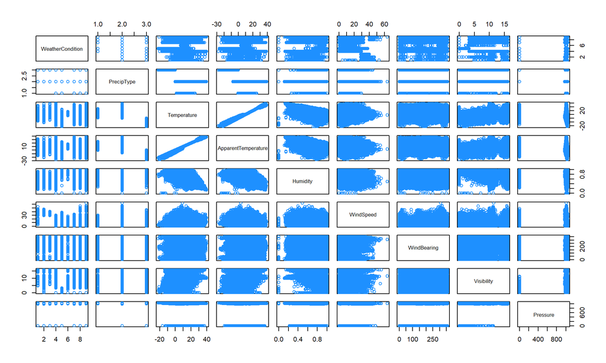

```r
#Identifying relationship among dataset variables

pairs(weather_data, col="dodgerblue")
```

*Based on the correlation plot shown above, the predictors Temperature and Apparent Temperature have high collinearity.* Converting factor variables to numeric to observe collinearity.

```r
weather_data$WeatherCondition = as.numeric(weather_data$WeatherCondition)
weather_data$`PrecipType`= as.numeric(weather_data$`PrecipType`)
```

**Identifying Collinearity**

```r
library(faraway)
(cor_data = cor(weather_data))
```

```
##                     WeatherCondition PrecipType Temperature ApparentTemperature
## WeatherCondition             1.00000  -0.128925    0.214564            0.210386
## PrecipType                  -0.12892   1.000000   -0.542245           -0.545264
## Temperature                  0.21456  -0.542245    1.000000            0.992629
## ApparentTemperature          0.21039  -0.545264    0.992629            1.000000
## Humidity                    -0.18339   0.223896   -0.632255           -0.602571
## WindSpeed                   -0.04981  -0.068319    0.008957           -0.056650
## WindBearing                  0.01782  -0.040390    0.029988            0.029031
## Visibility                   0.22164  -0.291999    0.392847            0.381718
## Pressure                     0.12226   0.006472   -0.005447           -0.000219
##                       Humidity WindSpeed WindBearing Visibility  Pressure
## WeatherCondition    -0.1833869 -0.049811   0.0178236    0.22164  0.122264
## PrecipType           0.2238959 -0.068319  -0.0403900   -0.29200  0.006472
## Temperature         -0.6322547  0.008957   0.0299882    0.39285 -0.005447
## ApparentTemperature -0.6025710 -0.056650   0.0290305    0.38172 -0.000219
## Humidity             1.0000000 -0.224951   0.0007346   -0.36917  0.005454
## WindSpeed           -0.2249515  1.000000   0.1038215    0.10075 -0.049263
## WindBearing          0.0007346  0.103822   1.0000000    0.04759 -0.011651
## Visibility          -0.3691725  0.100749   0.0475942    1.00000  0.059818
## Pressure             0.0054543 -0.049263  -0.0116509    0.05982  1.000000
```

```r
vif(weather_data) > 5
```

```
##    WeatherCondition          PrecipType         Temperature ApparentTemperature
##               FALSE               FALSE                TRUE                TRUE
##            Humidity           WindSpeed         WindBearing          Visibility
##               FALSE               FALSE               FALSE               FALSE
##            Pressure
##               FALSE
```

Since these two columns have high collinearity, we can remove Apparent Temperature and keep only Temperature for our model building.

## **Methods**

**Model Building**

```r
#Split the dataset for Train and Test (70:30)

set.seed(42)
trn_indx = sample(nrow(weather_data), 67000)
weather_data_trn = weather_data[trn_indx, ]
weather_data_tst = weather_data[-trn_indx, ]
```

**Model Evaluation**

```r
library(lmtest)
get_bp_pval = function(model) {
  bptest(model)$p.value[[1]]
}

get_bp_decision = function(model, alpha) {
  decide = unname(bptest(model)$p.value < alpha)
  ifelse(decide, "Reject", "Fail to Reject")
}

get_num_params = function(model) {
  length(coef(model))
}

get_loocv_rmse = function(model) {
  sqrt(mean((resid(model) / (1 - hatvalues(model))) ^ 2))
}

get_adj_r2 = function(model) {
  round(summary(model)$adj.r.squared*100,2)
  }

get_performance = function(model) {
  data.frame(Param = get_num_params(model), LOOCV_RMSE = get_loocv_rmse(model), R2 = round(summary(model)$r.squared*100,2), Adj_R2 = get_adj_r2(model), BP_pval = get_bp_pval(model))
  }
```

```r
diagnostics = function(model, pcol = "grey", lcol = "dodgerblue", alpha = 0.05,
                       plotit = TRUE, testit = TRUE) {

  if (plotit == TRUE) {

    # side-by-side plots (one row, two columns)
    par(mfrow = c(1, 2))

    # fitted versus residuals
    plot(fitted(model), resid(model),
         col = pcol, pch = 20, cex = 1.5,
         xlab = "Fitted", ylab = "Residuals",
         main = "Fitted versus Residuals")
    abline(h = 0, col = lcol, lwd = 2)

    grid()

    # qq-plot
    qqnorm(resid(model), col = pcol, pch = 20, cex = 1.5)
    qqline(resid(model), col = lcol, lwd = 2)
    grid()
  }


}
```

```r
# Initial Model

model_init = lm(Visibility ~ .-ApparentTemperature, data = weather_data_trn)
```

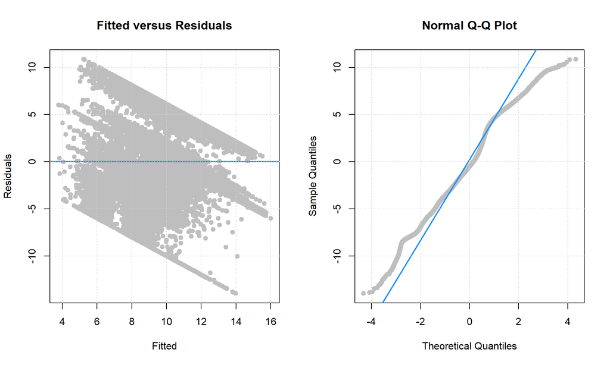

```r
diagnostics(model_init)
```

**Model Assumptions**

- Based on above Fitted vs Residual plot, the equivariance and linearity assumption are suspected.For some of the datapoints, the model is overfitting and for some of the datapoints the model is underfitting.
- Based on the Normal Q-Q plot above, the normality assumption of the model is suspected.

```r
# Additional Model Evaluation Metrics

get_loocv_rmse(model_init)
```

```
## [1] 3.704
```

```r
get_adj_r2(model_init)
```

```
## [1] 21.86
```

```r
get_bp_decision(model_init, alpha = 0.05)
```

```
## [1] "Reject"
```

```r
get_num_params(model_init)
```

```
## [1] 8
```

```r
bptest(model_init)
```

```
##
##  studentized Breusch-Pagan test
##
## data:  model_init
## BP = 9355, df = 7, p-value <2e-16
```

- Based on the above results, the adjusted $R^2$ of 21.86 is very low. Therefore, the change in visibility can’t be explained properly by linear relationship with predictors.
- The `p-value` out of Breusch-Pagan test is also very low. Therefore, the equivariance assumption is suspected.

** Start Model Improvements **

```r
# Use backward search AIC
model_aic_add = step(model_init, trace = FALSE)
```

```r
# Backward search BIC
n = length(resid(model_init))
model_bic_add = step(model_init, k = log(n), trace = FALSE)
```

```r
get_adj_r2(model_aic_add)
```

```
## [1] 21.86
```

```r
get_adj_r2(model_bic_add)
```

```
## [1] 21.86
```

## Below is our analysis with interaction model having all the predictors :

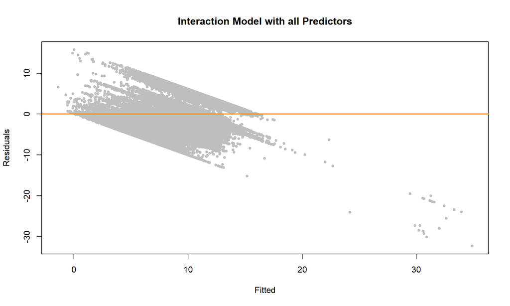

```r
# Interaction Model
weather_model_int = lm(Visibility ~ .^2, data = weather_data)

rsquared_int = summary(weather_model_int)$r.squared

plot(fitted(weather_model_int), resid(weather_model_int), col = "grey", pch = 20,
xlab = "Fitted", ylab = "Residuals", main = "Interaction Model with all Predictors")
abline(h = 0, col = "darkorange", lwd = 2)
```

- The R-Squared value for the interaction model is $36.29$, but based on the Fitted vs Residual plot we can clearly see that the model assumptions has been violated.
- We are also seeing some influential observations affecting the regression. Removing influential observations them and fit the model again expecting the significance of regression will improve.
- We are removing $4151$, influential observations from our fitted model.

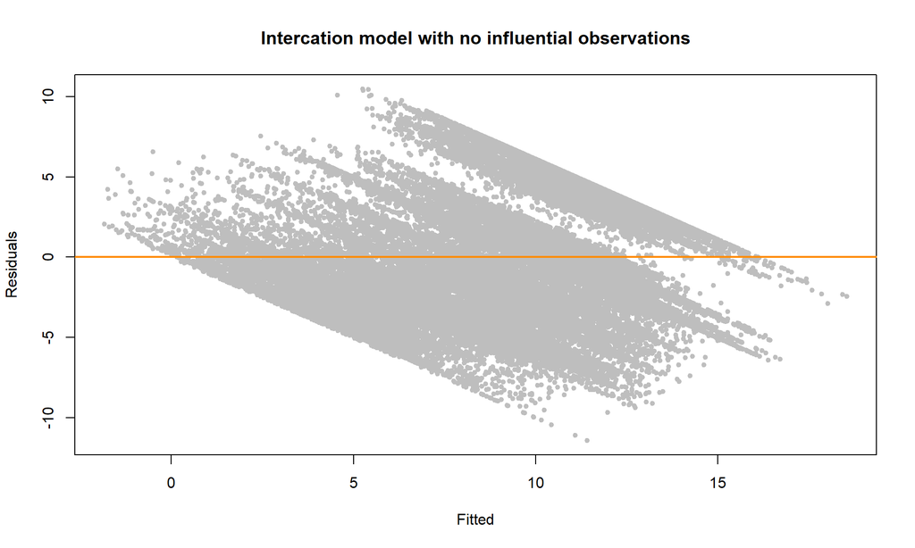

```r
# Interaction Model after removing Influential Observations
weather_model_int_low_influence = lm(Visibility ~ .^2, data = weather_data,
                            subset = cooks.distance(weather_model_int) <= 4/nrow(weather_data))

rsquared_low_influence = summary(weather_model_int_low_influence)$r.squared

plot(fitted(weather_model_int_low_influence), resid(weather_model_int_low_influence), col = "grey", pch = 20,
xlab = "Fitted", ylab = "Residuals", main = "Intercation model with no influential observations")
abline(h = 0, col = "darkorange", lwd = 2)
```

- The R-Squared of the model after removing influential observations is calculated to $43.86$, which is a improved value than the previous model.
- But the Fitted vs Residual plot is still showing violations in assumptions.
- With the expectation to improve the model, we are performing `Backword BIC` on the previous interaction model to see if it can better explain the variability of our response.

```r
weather_model_int_bic = step(weather_model_int, k=log(nrow(weather_data)), trace = 0)

rsquared_int_bic = summary(weather_model_int_bic)$r.squared
```

- The R-Squared after performing the BIC is calculated to $36.26$.
- And as we can see that the value is not improving much with the previous attempts on interaction models, we are trying on a log transformation of the Response

## Below is our analysis with log transformation and interaction with all predictors.

```r
any(is.infinite(log(weather_data$Visibility)))
```

```
## [1] TRUE
```

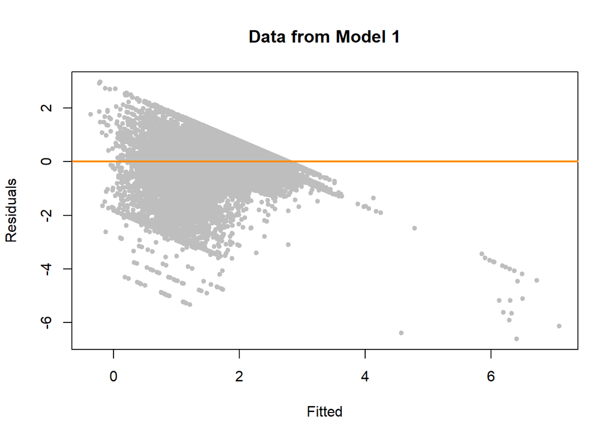

```r
weather_model_log_int = lm(log(Visibility) ~ .^2, data = weather_data,
                            subset = is.finite(log(weather_data$Visibility)))

plot(fitted(weather_model_log_int), resid(weather_model_log_int), col = "grey", pch = 20,
xlab = "Fitted", ylab = "Residuals", main = "Data from Model 1")
abline(h = 0, col = "darkorange", lwd = 2)
```

```r
rsquared_log_interaction = summary(weather_model_log_int)$r.squared
```

- We see a much improved value of R-Squared calculated to $44.56$, but Fitted vs Residual plot showing violation with `Equal Variance` assumption of our linear model.
- We are removing influential observations from our data and fitting the model again to achieve a better plot.

```r
rows_removed = sum((as.numeric(weather_data$Visibility) == 0))
weather_data = weather_data[(as.numeric(weather_data$Visibility) != 0),]
```

- As `0` value in Visibility is not feasible for our Response, we have decided to remove $450$ observation having `0` value for the Visibility column.

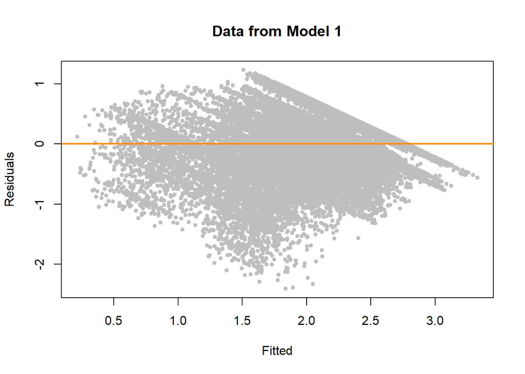

```r
library(lmtest)
weather_model_log_int_low_influence = lm(log(Visibility) ~ .^2, data = weather_data,
                            subset = cooks.distance(weather_model_log_int) <= 4/nrow(weather_data))

plot(fitted(weather_model_log_int_low_influence), resid(weather_model_log_int_low_influence), col = "grey", pch = 20,
xlab = "Fitted", ylab = "Residuals", main = "Data from Model 1")
abline(h = 0, col = "darkorange", lwd = 2)
```

```r
rsquared_log_interaction_low_influence = summary(weather_model_log_int_low_influence)$r.squared

bptest(weather_model_log_int_low_influence)$p.value
```

```
## BP
##  0
```

## Below is our analysis with polynomial transformation.

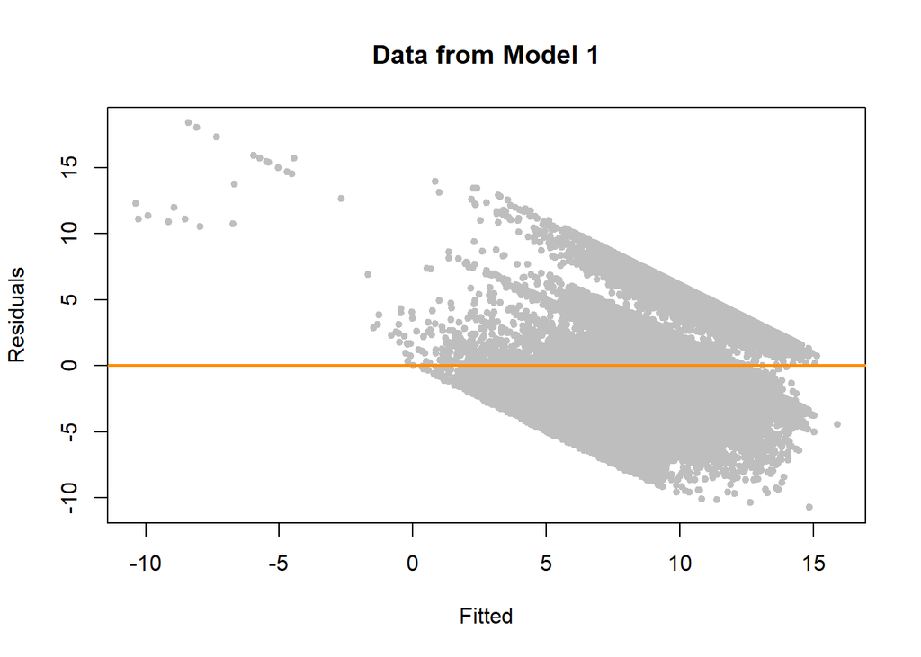

```r
weather_model_poly = lm(Visibility ~ . +
                           I(Temperature^2) +
                           I(Humidity^2) +
                           I(WindSpeed^2) +
                           I(WindBearing^2) +
                           I(Pressure^2) , data = weather_data)

rsquared_poly = summary(weather_model_poly)$r.squared


plot(fitted(weather_model_poly), resid(weather_model_poly), col = "grey", pch = 20,
xlab = "Fitted", ylab = "Residuals", main = "Data from Model 1")
abline(h = 0, col = "darkorange", lwd = 2)
```

- The R-Squared value, 36.31 didn’t improved much from our previous model and the Fitted vs Residual plot also showing violations of assumptions.

```r
weather_data$Temperature = (weather_data$Temperature * (9 /5)) + 32
```

```r
int_mod = lm(sqrt(Visibility) ~ PrecipType * Summary * sqrt(sqrt(Temperature^2)) * Humidity, data = weather_data_trn)
#subset = is.finite(log(weather_data$Visibility)
```

```r
int2_mod = lm (sqrt(Visibility) ~ PrecipType * Summary * sqrt(sqrt(Temperature^2)) * Humidity, data = weather_data_trn, subset=cooks.distance(int_mod) <= 4 / nrow(weather_data3_trn))
```

```r
visibility_inf = cooks.distance(int_mod) > 4 / nrow(weather_data_trn)
visibility_cd = weather_data_trn$Visibility[(cooks.distance(int_mod) <= 4 / nrow(weather_data_trn)),]
```

```r
sum(visibility_inf)
```

[output not shown]

```r
summary(int_mod)$r.squared
summary(int2_mod)$r.squared
```

[output not shown]

```r
#aic
aic_mod = step(int_mod, direction="backward", trace=0)
aic_mod
```

[output not shown]

```r
summary(aic_mod)
```

[output not shown]

```r
# Make functions to evaluate and summarize model performance
library(lmtest)
get_bp_pval = function(model) {
  bptest(model)$p.value[[1]]
}
get_bp_decision = function(model, alpha) {
  decide = unname(bptest(model)$p.value < alpha)
  ifelse(decide, "Reject", "Fail to Reject")
}
get_sw_decision = function(model, alpha) {
  decide = unname(shapiro.test(resid(model))$p.value < alpha)
  ifelse(decide, "Reject", "Fail to Reject")
}
get_num_params = function(model) {
  length(coef(model))
}
get_loocv_rmse = function(model1) {
  sqrt(mean(((int_mod$model$`sqrt(Visibility)` - (fitted(model1))) / (1 - hatvalues(model1))) ^ 2))
}
get_adj_r2 = function(model) {
  summary(model)$adj.r.squared}
  get_performance = function(model) {
  data.frame(Param = get_num_params(model), LOOCV_RMSE = get_loocv_rmse(model), R2 = summary(model)$r.squared, Adj_R2 = get_adj_r2(model), BP_pval = get_bp_pval(model))

  }
```

```r
int2_mod$model
```

[output not shown]

```r
#Define a diagnostics function, this is obtained from the homework#8
diagnostics = function(model1, pcol = "grey", lcol = "dodgerblue", alpha = 0.05,
                       plotit = TRUE, testit = TRUE) {

  if (plotit == TRUE) {

    # side-by-side plots (one row, two columns)
    par(mfrow = c(1, 2))

    # fitted versus residuals
    plot(fitted(model1), (int2_mod$model$`sqrt(Visibility)` - (fitted(model1))),
         col = pcol, pch = 20, cex = 1.5,
         xlab = "Fitted", ylab = "Residuals",
         main = "Fitted versus Residuals")
    abline(h = 0, col = lcol, lwd = 2)
    grid()

    # qq-plot
    qqnorm((int2_mod$model$`sqrt(Visibility)` - (fitted(model1))), col = pcol, pch = 20, cex = 1.5)
    qqline((int2_mod$model$`sqrt(Visibility)` - (fitted(model1))), col = lcol, lwd = 2)
    grid()
  }
}
```

```r
# Training RMSE
sqrt(mean(((int2_mod$model$`sqrt(Visibility)` - (fitted(int2_mod))) ^ 2)))
```

[output not shown]

```r
#Predict
pred_tst = predict(int2_mod, newdata = weather_data3_tst)
```

```r
(test_rmse = sqrt(mean((weather_data_tst$Visibility - (pred_tst^2)) ^2)))
```

[output not shown]

```r
diagnostics(int2_mod)
get_loocv_rmse(int_mod)
get_adj_r2(int_mod)
get_bp_decision(int2_mod, alpha = 0.05)
get_num_params(int_mod)
bptest(int2_mod)
```

[output not shown]

```r
# Evaluate performance of initial models
kable(rbind(init = get_performance(int2_mod), add = get_performance(int_mod)))
```

[output not shown]

```r
aic_mod = step(int_mod, step = "backward", trace = 0)
aic_mod
```

[output not shown]